# Bayesian retrospective power analysis

**Table of contents:**

- Introduction
- Procedure
- The statistical model
- Points where Bayesian estimation shines
- Software code
  - Create some fake data
  - Learn the data generating distribution
  - Sanity check
  - Generate batches of data
  - Aside: meaning of Bayesian credible interval
  - Aside: meaning of frequentist confidence interval
  - Count the number of successful experiments
  - Determine the power of the experiment

## Introduction

Quote from Kruschke2013 (p. 583), paraphrased and adapted to the situation:

> Suppose I think that a realistic sample size for my study will have $N = 50$. Suppose I have several goals for the analysis, selected here more for illustrative purposes than for realism. With regard to the magnitude of $\Delta\alpha$ (the difference between the doctor’s and the software’s output for any image), suppose I would like to show that its 95% HDI (highest density posterior interval; a.k.a. HPD) falls entirely within a ROPE (range of practical equivalence) of $(-5^\circ, 5^\circ)$, which is to say that after these experiments we believe the difference between the doctor’s and the software’s prediction is not more different than $5^\circ$.

We can increase power by increasing the experiment’s sample size or by targeting a simpler goal (e.g. a wider ROPE).

*Figure 6* of Kruschke2013:

[figure not shown]

> Flowchart for estimating Bayesian power. At the left, a hypothetical distribution of parameter values is used to repeatedly generate representative credible parameter values. For each set of parameter values, a simulated sample of data is generated from the model. Then Bayes’ rule is applied to derive the posterior distribution from the simulated data and assay whether the various goals have been achieved for that sample. Across many replications of simulated experiments, the probability of achieving each goal is estimated to arbitrarily high accuracy.

## Procedure

1. Take all the labeled images we have.
2. Fit the statistical model to the training data to define the plausible parameter values.
3. Using this posterior, simulate $S$ batches of $N$ samples. **(Note: steps 1–3 of inferring a distribution of plausible parameter values can be done with a Bayesian model even if we intend to provide confidence, and they would result in better estimates for power analysis than a simple point estimate of the parameters.)**
4. Fit the model independently to these $S$ batches of generated data.
5. Count the number of batches where the 95% HDI fits entirely within the ROPE ($n_{succ}$), and where it falls entirely outside the ROPE ($n_{fail}$).
6. Assuming a uniform prior on a correct software (with differences from ground truth inside the ROPE), we can use the binomial observations $n_{succ}$ out of $S$ to update this model, resulting in a $\text{Beta}(1+n_{succ}, 1 + S - n_{succ})$ posterior for *demonstrably* correct software. (Using $n_{fail}$, we can do a similar analysis for demonstrably *incorrect* software.) **(Note: we can use the binomial model in this step even if we do the previous steps using confidence intervals or any other success criterion.)**

## The statistical model

Instead of directly modeling the angles returned by the doctors and the software, I first model the distribution of the three points A, B, C, then the output of both the doctors ($A_{doc}$) and the software ($A_{sw}$) as the true point ± some error ($\sigma_{doc}$ and $\sigma_{sw}$), and from these I calculate the angles and the error of the software ($\Delta\alpha = \alpha_{doc} - \alpha_{sw}$). (It would make perfect sense to model $\Delta\alpha$ as $\alpha_{true} - \alpha_{sw}$ instead of $\alpha_{doc} - \alpha_{sw}$, but that would take some arguing.) This allows me to estimate the angle error much more precisely, instead of just blindly assuming e.g. a normal distribution on $\Delta\alpha$.

[figure not shown]

Note that even the doctors don’t know the true point, but this need not adversely affect the calculations: in step 4 (and during the clinical trial), we can simply assume a near-zero value of $\sigma_{doc}$.

Modeling the 3 points throughout the whole population as independent distributions would be a bad fit – they are obviously not independent (e.g. hip size affects all). It is better to use a coordinate system with one of the 3 points of the expert evaluation as the origin, instead of using a global coordinate system where all 3 points vary. I chose the inner point of the hip as the origin so that the angle is always positive – therefore $C_{true} = C_{doc} = C_{sw} = (0,0)$. (In practice this assumption would need some fine-tuning, because this now assumes that one point is always estimated precisely).

## Points where Bayesian estimation shines

### Hierarchical models

Hierarchical models can be handled easily in a Bayesian setting, whereas they are considerably more complicated using frequentist statistics. Such models could be used for many purposes, and they all improve the precision of the model.

a) Model the uncertainty in the points, instead of the angles.

b) Combine multiple expert evaluations of the same image in the same model, thus decreasing the model’s uncertainty in the expert opinions.

c) By keeping track of which doctor made the analysis, we can assign different “carelessness” factors to the each doctor, instead of using the same $\sigma_{doc}$ for all of them.

### Power analysis

According to Kruschke2013, Bayesian power analysis results in more precise power estimates than NHST (null hypothesis significance testing) power analysis:

> In either retrospective or prospective power analyses, NHST uses a point value for the hypothetical effect size. In Bayesian power analysis, one uses an entire distribution of parameters instead of a single point value for the effect size. Thus, every value of effect size is considered but only to the extent that it is considered to be credible. NHST power analysis can consider various point values, such as the end points of a confidence interval, but the different point values are not weighted by credibility and therefore can yield a huge range of powers. As a consequence, **NHST power analysis often yields extremely uncertain results** (e.g., Gerard et al., 1998; Miller, 2009; Thomas, 1997), **but Bayesian power analysis yields precise estimates of power.**

### Adaptive experiment design

Stopping an experiment early (when the results are conclusive) doesn’t require further care in a Bayesian setting, whereas multiple books and [papers](https://www.onlinelibrary.wiley.com/doi/full/10.1002/sim.6472) are written on adaptive design for frequentist statistics, as the testing intentions affect the confidence intervals.

## Code

```python
import numpy as np
import scipy.stats as st
import matplotlib.pyplot as plt
import pystan
import arviz as az
from tqdm import trange

plt.rc('font', size=14)
plt.rc('axes', grid=True)
```

### Create some fake data

As I don’t have labeled images, I am generating samples manually.

```python
def truncated_multivariate_normal(mean, sigma):
    """Returns a sample from a truncated multivariate normal distribution

    truncated to 2 sigma around the mean."""
    assert isinstance(sigma, float) or isinstance(sigma, int)
    proposal = np.array(np.inf)
    while np.linalg.norm(proposal - mean) > 2 * sigma:
        proposal = st.multivariate_normal(mean=mean, cov=np.ones_like(mean) * sigma).rvs(1)
    return proposal
```

First, 20 samples of true points.

```python
# the sample data is generated using fixed parameter values
N_train = 20

# origin: C
# units: mm
A_population_mean = [-5, -2]
B_population_mean = [-10, -18]
C_population_mean = [0, 0]

A_population_std = 1  # units: mm
B_population_std = 1

A_true = np.array([truncated_multivariate_normal(A_population_mean, A_population_std)
                   for _ in range(N_train)])
B_true = np.array([truncated_multivariate_normal(B_population_mean, B_population_std)
                   for _ in range(N_train)])
C_true = np.zeros((N_train, 2))
```

Then 20 samples of doctor estimates and software estiamtes.

```python
sigma_doc = 1
sigma_sw = 1
```

```python
A_doc = np.empty_like(A_true)
B_doc = np.empty_like(B_true)
C_doc = np.zeros_like(C_true)

A_sw = np.empty_like(A_true)
B_sw = np.empty_like(B_true)
C_sw = np.zeros_like(C_true)

for i in range(N_train):
    A_doc[i] = truncated_multivariate_normal(A_true[i], sigma_doc)
    B_doc[i] = truncated_multivariate_normal(B_true[i], sigma_doc)

    A_sw[i] = truncated_multivariate_normal(A_true[i], sigma_doc)
    B_sw[i] = truncated_multivariate_normal(B_true[i], sigma_doc)
```

Plot our points:

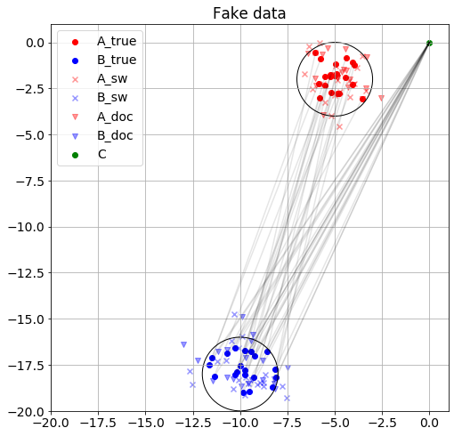

```python
_, ax = plt.subplots(figsize=(8,8))

for a, b in zip(A_true, B_true):
    plt.plot([a[0], b[0], 0], [a[1], b[1], 0], c='k', alpha=0.1)

plt.scatter(A_true[:, 0], A_true[:, 1], c='r', label='A_true')
plt.scatter(B_true[:, 0], B_true[:, 1], c='b', label='B_true')
plt.scatter(A_sw[:, 0], A_sw[:, 1], c='r', marker='x', label='A_sw', alpha=0.4)
plt.scatter(B_sw[:, 0], B_sw[:, 1], c='b', marker='x', label='B_sw', alpha=0.4)
plt.scatter(A_doc[:, 0], A_doc[:, 1], c='r', marker='v', label='A_doc', alpha=0.4)
plt.scatter(B_doc[:, 0], B_doc[:, 1], c='b', marker='v', label='B_doc', alpha=0.4)
plt.scatter(0, 0, c='g', label='C')

circle_A = plt.Circle(A_population_mean, 2 * A_population_std, fill=False)
circle_B = plt.Circle(B_population_mean, 2 * B_population_std, fill=False)

ax.add_artist(circle_A)
ax.add_artist(circle_B)

plt.ylim(-20, 1)
plt.xlim(-20, 1)

plt.legend()
plt.title('Fake data')
plt.show()
```

### Learn the data generating distribution

We use the [Python interface](https://pystan.readthedocs.io/) of the statistical modeling software [Stan](https://mc-stan.org/). Instead of modeling the end result (the angles, or the difference between the angle predicted by the doctor and the software), we model the variance around the true points, both for the doctors and the software.

Stan has its own modeling language, and requires compiling the model before sampling.

```python
model_code = """

functions {
    /* Given 2-dimensional vectors A and B,
       calculate the angle ABO */
    real angle(vector A_pt, vector B_pt)
    {
        vector[2] v1;
        vector[2] v2;

        v1 = A_pt - B_pt;
        v2 = -B_pt;

        return acos(dot_product(v1, v2) /
                    sqrt(dot_product(v1, v1) * dot_product(v2, v2))) \
                    * 180 / pi();
    }
}

data {
    int<lower=0> N; // number of data points
    vector[2] A_doc[N];
    vector[2] B_doc[N];
    vector[2] A_sw[N];
    vector[2] B_sw[N];

    real<lower=0> sigma_doc; // some small number
}

parameters {
    // log(sigma) has an improper uniform prior on it,
    //  for A_population_sigma, B_population_sigma, sigma_sw
    real log_sigma_sw;

    real log_A_population_sigma;
    real log_B_population_sigma;

    // A_population_mean and B_population_mean also have an improper uniform prior on them
    vector[2] A_population_mean;
    vector[2] B_population_mean;

    vector[2] A_true[N];
    vector[2] B_true[N];

    // These are points sampled from the posterior,
    //  not the observed points.
    vector[2] A_true_;
    vector[2] B_true_;
    vector[2] A_doc_;
    vector[2] A_sw_;
    vector[2] B_doc_;
    vector[2] B_sw_;
}

transformed parameters {
    real<lower=0> A_population_sigma;
    real<lower=0> B_population_sigma;
    real<lower=0> sigma_sw;

    real alpha_doc;
    real alpha_sw;
    real alpha_diff;

    A_population_sigma = exp(log_A_population_sigma);
    B_population_sigma = exp(log_B_population_sigma);
    sigma_sw = exp(log_sigma_sw);

    alpha_doc = angle(A_doc_, B_doc_);
    alpha_sw = angle(A_sw_, B_sw_);

    alpha_diff = alpha_doc - alpha_sw;
}

model {
    for (n in 1:N) {
        A_true[n] ~ normal(A_population_mean, A_population_sigma);
        B_true[n] ~ normal(B_population_mean, B_population_sigma);

        A_doc[n] ~ normal(A_true[n], sigma_doc);
        B_doc[n] ~ normal(B_true[n], sigma_doc);

        A_sw[n] ~ normal(A_true[n], sigma_sw);
        B_sw[n] ~ normal(B_true[n], sigma_sw);
    }


    A_true_ ~ normal(A_population_mean, A_population_sigma);
    B_true_ ~ normal(B_population_mean, B_population_sigma);

    A_doc_ ~ normal(A_true_, sigma_doc);
    B_doc_ ~ normal(B_true_, sigma_doc);

    A_sw_ ~ normal(A_true_, sigma_sw);
    B_sw_ ~ normal(B_true_, sigma_sw);
}
"""

model = pystan.StanModel(model_code=model_code)
```

```
INFO:pystan:COMPILING THE C++ CODE FOR MODEL anon_model_0f4652685e1020bca7c16379eeb1a0d6 NOW.
```

```python
stan_data = {
    'A_doc': A_doc,
    'B_doc': B_doc,
    'A_sw': A_sw,
    'B_sw': B_sw,
    'N': N_train,
    # For generating data, we want to be as realistic as possible,
    #  therefore we're not assuming doctors are super-accurate.
    #  (Ideally we would infer sigma_doc from multiple doctor's evaluation
    #   of the same image, and thus have a distribution on it instead of
    #   a fixed ad-hoc number.)
    # But if we set it to 1, the sampler has troubles,
    #  which we could solve by using a non-centered normal distribution,
    #  but let's just stick to this version now.
    'sigma_doc': 0.1
}
```

Here we fit the model to the data:

```python
stan_fit = model.sampling(data=stan_data, iter=1000)
```

Sample statistics of the posterior, including the mean, standard deviation, and various percentiles.

```python
print(stan_fit.stansummary())
```

```
Inference for Stan model: anon_model_0f4652685e1020bca7c16379eeb1a0d6.
4 chains, each with iter=1000; warmup=500; thin=1;
post-warmup draws per chain=500, total post-warmup draws=2000.

                         mean se_mean     sd   2.5%    25%    50%    75%  97.5%  n_eff   Rhat
log_sigma_sw             0.09  1.5e-3   0.08  -0.06   0.04   0.09   0.15   0.26   2908    1.0
log_A_population_sigma  -0.01  2.2e-3   0.11  -0.22  -0.09  -0.02   0.06   0.22   2540    1.0
log_B_population_sigma   0.25  2.3e-3   0.12   0.03   0.16   0.25   0.33    0.5   2657    1.0
A_population_mean[1]    -4.66  4.2e-3   0.22   -5.1   -4.8  -4.65  -4.52  -4.23   2673    1.0
A_population_mean[2]    -1.82  4.2e-3   0.22  -2.25  -1.96  -1.83  -1.66   -1.4   2816    1.0
B_population_mean[1]    -9.83  6.0e-3   0.29 -10.43 -10.02  -9.83  -9.62  -9.26   2427    1.0
B_population_mean[2]   -17.51  5.4e-3   0.29 -18.04  -17.7  -17.5 -17.31 -16.93   2803    1.0
A_true[1,1]             -4.53  1.6e-3    0.1  -4.72   -4.6  -4.53  -4.47  -4.34   3649    1.0
A_true[2,1]             -4.85  1.7e-3    0.1  -5.05  -4.91  -4.85  -4.79  -4.66   3479    1.0
A_true[3,1]              -5.6  1.8e-3    0.1  -5.79  -5.66   -5.6  -5.53  -5.41   3100    1.0
A_true[4,1]             -5.65  1.7e-3    0.1  -5.84  -5.71  -5.65  -5.58  -5.45   3460    1.0
A_true[5,1]              -4.0  1.7e-3    0.1  -4.19  -4.07   -4.0  -3.94  -3.82   3304    1.0
A_true[6,1]             -5.03  1.8e-3    0.1  -5.23   -5.1  -5.03  -4.96  -4.83   3184    1.0
A_true[7,1]             -3.37  1.8e-3    0.1  -3.55  -3.43  -3.37   -3.3  -3.18   3046    1.0
A_true[8,1]             -4.41  1.6e-3    0.1  -4.61  -4.48  -4.41  -4.35  -4.22   3628    1.0
A_true[9,1]              -4.2  1.5e-3    0.1  -4.39  -4.27   -4.2  -4.13  -4.01   4104    1.0
A_true[10,1]            -6.02  1.8e-3    0.1  -6.22  -6.09  -6.02  -5.96  -5.82   3024    1.0
A_true[11,1]            -3.31  1.6e-3    0.1   -3.5  -3.37  -3.31  -3.24  -3.11   3581    1.0
A_true[12,1]             -2.6  1.7e-3    0.1   -2.8  -2.67   -2.6  -2.53   -2.4   3502    1.0
A_true[13,1]            -4.33  1.8e-3    0.1  -4.53   -4.4  -4.33  -4.27  -4.14   3183    1.0
A_true[14,1]            -5.99  1.7e-3    0.1  -6.19  -6.05  -5.99  -5.93   -5.8   3500    1.0
A_true[15,1]            -5.35  1.9e-3    0.1  -5.55  -5.42  -5.35  -5.29  -5.16   2812    1.0
A_true[16,1]            -6.38  1.6e-3    0.1  -6.56  -6.44  -6.38  -6.31  -6.19   3818    1.0
A_true[17,1]            -4.63  1.6e-3    0.1  -4.81  -4.69  -4.63  -4.56  -4.44   3838    1.0
A_true[18,1]            -3.57  1.7e-3    0.1  -3.78  -3.64  -3.57   -3.5  -3.37   3821    1.0
A_true[19,1]            -4.86  1.7e-3    0.1  -5.06  -4.93  -4.86  -4.79  -4.66   3533    1.0
A_true[20,1]            -4.46  1.6e-3    0.1  -4.66  -4.53  -4.46   -4.4  -4.26   4034    1.0
A_true[1,2]             -1.47  1.7e-3    0.1  -1.65  -1.54  -1.47  -1.39  -1.27   3457    1.0
A_true[2,2]             -1.92  1.6e-3    0.1  -2.11  -1.99  -1.91  -1.85  -1.72   3892    1.0
A_true[3,2]             -3.89  1.6e-3    0.1  -4.08  -3.96  -3.89  -3.83  -3.71   3783    1.0
A_true[4,2]             -0.65  1.8e-3    0.1  -0.85  -0.72  -0.65  -0.58  -0.44   3153    1.0
A_true[5,2]             -2.28  1.8e-3    0.1  -2.47  -2.34  -2.28  -2.21  -2.08   2909    1.0
A_true[6,2]             -1.78  1.7e-3    0.1  -1.97  -1.85  -1.78  -1.71  -1.58   3376    1.0
A_true[7,2]             -2.47  1.6e-3    0.1  -2.66  -2.54  -2.48   -2.4  -2.28   3763    1.0
A_true[8,2]              -1.5  1.6e-3    0.1   -1.7  -1.57   -1.5  -1.43   -1.3   3681    1.0
```

[output cut: 61 more lines]

```
B_doc_[2]               -17.5    0.03   1.34 -20.09 -18.38 -17.49 -16.57 -14.92   1865    1.0
B_sw_[1]                -9.83    0.04   1.76 -13.22 -11.04  -9.83  -8.62  -6.36   1670    1.0
B_sw_[2]               -17.47    0.04   1.75 -20.93 -18.64 -17.41 -16.25 -14.07   2001    1.0
A_population_sigma       0.99  2.3e-3   0.11    0.8   0.91   0.98   1.06   1.25   2456    1.0
B_population_sigma       1.29  3.2e-3   0.16   1.03   1.18   1.28   1.38   1.66   2492    1.0
sigma_sw                  1.1  1.7e-3   0.09   0.94   1.04    1.1   1.16    1.3   2862    1.0
alpha_doc               10.97     0.1   3.93   3.42   8.23  10.81  13.59  18.81   1597    1.0
alpha_sw                11.09    0.13   5.51   1.69   7.11  10.72  14.56  22.83   1789    1.0
alpha_diff              -0.11    0.08   4.05  -8.54  -2.68 6.2e-3   2.64    7.9   2576    1.0
lp__                   -144.0    0.26   7.11 -158.4 -148.5 -143.6 -139.0 -131.2    738    1.0

Samples were drawn using NUTS at Thu Oct 24 10:14:33 2019.
For each parameter, n_eff is a crude measure of effective sample size,
and Rhat is the potential scale reduction factor on split chains (at
convergence, Rhat=1).
```

### Sanity check

*Do the posteriors approximately match the real values?*

This is the sample mean of the true points:

```python
A_true.mean(axis=0)
```

```
array([-4.95193709, -1.8909093 ])
```

This is the posterior of the population means (left/right: x/y coordinates):

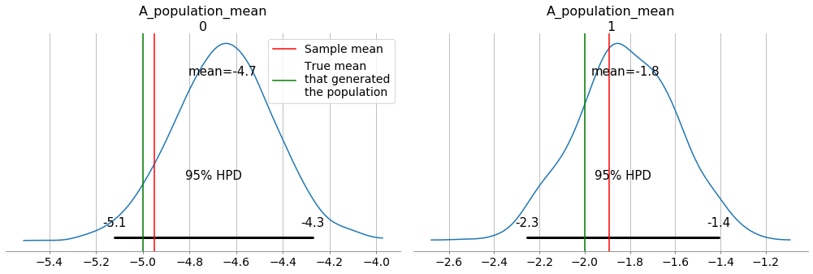

```python
axes = az.plot_posterior(stan_fit, 'A_population_mean', credible_interval=0.95)
axes[0].axvline(A_true.mean(0)[0], c='r', label='Sample mean')
axes[0].axvline(A_population_mean[0], c='g', label='True mean\nthat generated\nthe population')
axes[0].legend(loc='upper right')
axes[1].axvline(A_true.mean(0)[1], c='r')
axes[1].axvline(A_population_mean[1], c='g')

plt.show()
```

The sample mean just happens to be more positive than the green one, nothing to read into it.

Similar checks for the population standard deviations:

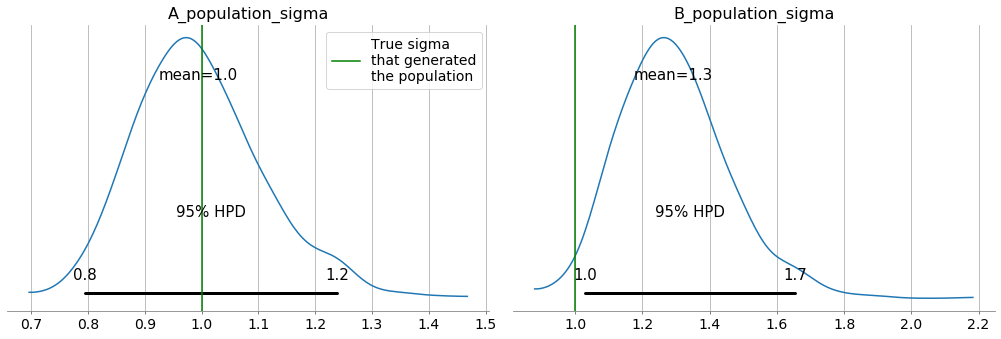

```python
axes = az.plot_posterior(stan_fit, ['A_population_sigma', 'B_population_sigma'], credible_interval=0.95)
axes[0].axvline(A_population_std, c='g', label='True sigma\nthat generated\nthe population')
axes[0].legend()
axes[1].axvline(B_population_std, c='g')
plt.show()
```

```python
print('sample standard deviations (x,y):')
print('B_true:', B_true.std(0))
print('B_doc:', B_doc.std(0))
print('B_sw:', B_sw.std(0))
```

```
sample standard deviations (x,y):
B_true: [1.00665782 0.72375782]
B_doc: [1.38332745 1.06779693]
B_sw: [1.29301946 1.15789159]
```

#### Check our model of the points predicted by the software

```
array([<matplotlib.axes._subplots.AxesSubplot object at 0x128a2fe10>],
      dtype=object)
```

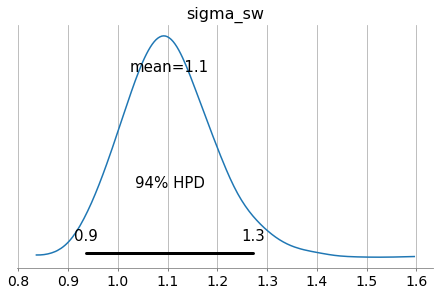

```python
az.plot_posterior(stan_fit, 'sigma_sw')
```

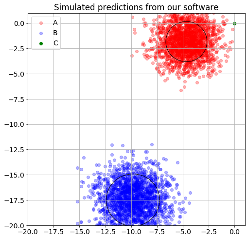

```python
_, ax = plt.subplots(figsize=(8,8))

plt.scatter(*(stan_fit['A_sw_'].T), c='r', label='A', alpha=0.3)
plt.scatter(*(stan_fit['B_sw_'].T), c='b', label='B', alpha=0.3)
plt.scatter(0, 0, c='g', label='C')

circle_A = plt.Circle(stan_fit['A_population_mean'].mean(0),
                      2 * stan_fit['A_population_sigma'].mean(0),
                      fill=False)
circle_B = plt.Circle(stan_fit['B_population_mean'].mean(0),
                      2 * stan_fit['B_population_sigma'].mean(0),
                      fill=False)

ax.add_artist(circle_A)
ax.add_artist(circle_B)

plt.ylim(-20, 1)
plt.xlim(-20, 1)

plt.legend()
plt.title('Simulated predictions from our software')
plt.show()
```

Clearly, these samples are way too spread out, and we could fine tune the model to match the data better and the distributions be narrower (e.g. by using bounded distributions), but for demonstration purposes it’s good enough.

### Generate batches of data

```python
# This many batches (the estimate of power is more accurate with more batches)
S = 20

# Example sample size (number of images to be analyzed by the doctors)
N = 100
```

```python
# generate a lot of samples (for the doctor and software evaluations)
stan_fit_big = model.sampling(data=stan_data, iter=(S * N))
```

```python
hpd_list = []

for s in trange(S):
    stan_data_experiment = {
        'N': N,
        # This time we are reproducing the conditions of the clinical trial,
        #  therefore we want to set sigma_doc to a low value,
        #  to show the skeptics that we're comparing our software's output
        #  to the doctor's output.
        'sigma_doc': 0.1
    }

    for x in ['A_doc', 'B_doc', 'A_sw', 'B_sw']:
        stan_data_experiment[x] = stan_fit_big[x + '_'][s*N : (s+1)*N]

    stan_fit_experiment = model.sampling(data=stan_data_experiment, iter=500)
    hpd_list.append(az.hpd(stan_fit_experiment['alpha_diff'], credible_interval=0.95))
```

```python
hpd_list
```

```
[array([-7.48433272,  7.88657829]),
 array([-8.67878167,  7.33134099]),
 array([-8.17476437,  7.48108206]),
 array([-9.22852651,  6.53295345]),
 array([-7.7103381 ,  8.42757366]),
 array([-7.32478722,  6.9840045 ]),
 array([-8.14953747,  8.02522761]),
 array([-7.06950974,  7.59010929]),
 array([-7.41493683,  6.93490708]),
 array([-7.69588862,  6.82921178]),
 array([-8.24541887,  7.73916391]),
 array([-7.02439142,  6.44274661]),
 array([-7.70532582,  6.93348436]),
 array([-6.65554407,  7.36271053]),
 array([-6.99220387,  7.60443308]),
 array([-7.4598127 ,  7.06215637]),
 array([-7.29457637,  7.19658731]),
 array([-8.27535261,  7.49651662]),
 array([-6.77290434,  7.26379525]),
 array([-8.49664571,  7.86942174])]
```

For comparison, the average widths of the `alpha_diff` 95% HPDs from N=100, N=20, N=3 replications are 15.0°, 15.4°, and 20.0° (simulations not shown here). This suggests that we couldn’t get much below 15° even with larger sample size, assuming the current model and the data used for the power analysis (which data was synthesized without domain knowledge).

### Aside: what is the meaning of 95% credible interval on `alpha_diff`?

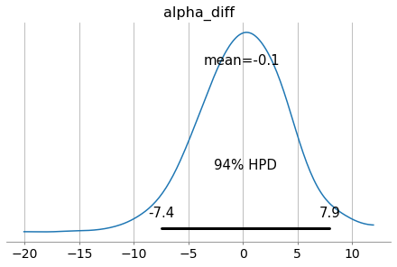

```python
az.plot_posterior(stan_fit, 'alpha_diff')
plt.show()
```

### Aside: what is the meaning of 95% confidence interval on $\overline{\Delta\alpha}$, given an experiment?

A 95% confidence interval $[\Delta\alpha_1, \Delta\alpha_2]$ means that if the true value of $\overline{\Delta\alpha}$ is outside this interval, then 5% of the experiments will show a more extreme test statistic than what was observed in this experiment.

Assuming a t-test is performed, the test statistic would be the t-statistic, and the meaning of CI would be: “if we assume $\Delta\alpha$ to be normally distributed with a given mean, then for any value $\delta$ inside the CI the observations are compatible with the hypothesis that the mean is $\delta$, whereas $\delta$ values outside the CI are quite incompatible”. Note that this doesn’t say *anything* about how wide is the distribution of $\Delta\alpha$ around $\delta$, as is demonstrated by the example below.

```python
N = 100
alpha_diff_values = stan_fit['alpha_diff'][:N]
st.t.interval(0.95, N-1, loc=np.mean(alpha_diff_values), scale=st.sem(alpha_diff_values))
```

```
(-0.9209289171827957, 0.6665510546672588)
```

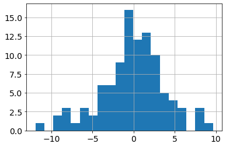

```python
plt.hist(alpha_diff_values, bins=20)
plt.show()
```

Furthermore, we can make the CI arbitrarily small, simply by using more samples. We are not changing the distribution of $\Delta\alpha$ *at all,* we are only increasing the precision of our estimate of the average error of the software

```python
N=1000
alpha_diff_values = stan_fit['alpha_diff'][:N]
st.t.interval(0.95, N-1, loc=np.mean(alpha_diff_values), scale=st.sem(alpha_diff_values))
```

```
(-0.2576941594761524, 0.23719033764084788)
```

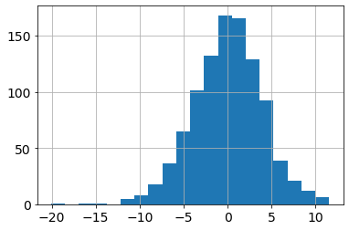

```python
plt.hist(alpha_diff_values, bins=20)
plt.show()
```

Long story short, any frequentist estimate of the average error $\overline{\Delta\alpha}$ is meaningless without an estimate of the standard deviation $sd(\Delta\alpha)$.

### Count the number of successful experiments

Experiment was successful if the HPD of `alpha_diff` fits entirely within the ROPE (range of practical equivalence) of $[-8^\circ, 8^\circ]$.

```python
hpd_min_crit, hpd_max_crit = -8, +8

n_succ = 0
for hpd in hpd_list:
    if (hpd[0] > hpd_min_crit and hpd[1] < hpd_max_crit):
        n_succ += 1

print(f'Successful experiments: {n_succ} out of {S}.')
```

```
Successful experiments: 12 out of 20.
```

### Determine the power of the experiment

We start out with a uniform prior about what we believe the power of the experiment could be.

```python
power_probabilities = np.linspace(0,1, 100)   # parameter space for our power estimation
power_prior = st.uniform.pdf(power_probabilities)
```

And update the prior according to the Binomial(S, p) likelihood, where S is the number of experiments simulated and *p* is the power.

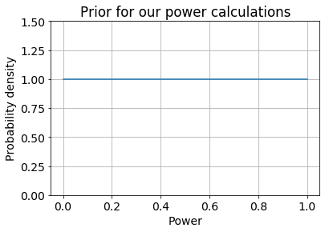

```python
plt.plot(power_probabilities, power_prior)
plt.title('Prior for our power calculations')
plt.xlabel('Power')
plt.ylabel('Probability density')
plt.ylim(0, 1.5)
plt.show()
```

```python
power_posterior = st.beta(1 + n_succ, 1 + (S - n_succ)).pdf(power_probabilities)
```

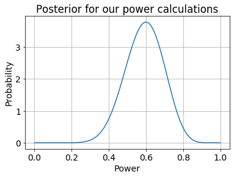

```python
plt.plot(power_probabilities, power_posterior)
plt.title('Posterior for our power calculations')
plt.xlabel('Power')
plt.ylabel('Probability')
plt.show()
```

This means that having seen these 20 simulations, we believe at least 30% of replications will be successful, but maybe as much as 85%.

## Contact me

If you liked what you saw above, you can contact me for consultation at laszlo.treszkai@gmail.com.